# R Code for Grouped Graphs Swirl Lesson

Marney Pratt

8/22/2020

# Load Packages and Import Data

```r
library(readr) ##for importing data
library(ggplot2)  ##for graphing
library(dplyr) ## for filtering, summarising, and other data wrangling
library(ggbeeswarm) #for making symmetrical jittering (beeswarm) of points
library(curl) #used for loading data from websites


#import hemlock data file
hemlock <- read_csv("https://docs.google.com/spreadsheets/d/e/2PACX-1vT-Uo5Gs2dcR6f6_PFrZwkaSrojsBCFt1qvVNU0PXn4RHVe3_GDzNL3BCxkkp6eIhjkfKw3S6YcX6wz/pub?output=csv",
                    col_types = cols(SamplingDate = col_date(format = "%m/%d/%Y"),
                                     Location = col_factor()))
```

# Bar Graph of Means and Standard Errors

```r
##calculate descriptive stats and SE for EHS density
EHS.sum <- hemlock %>%
  group_by(Location) %>%
  summarise(mean = mean(EHS),
            sd = sd(EHS),
            n = n()) %>%
  mutate(sem = sd/(sqrt(n)))
print(EHS.sum)
```

```
## # A tibble: 4 x 5
##   Location  mean    sd     n   sem
##   <fct>    <dbl> <dbl> <int> <dbl>
## 1 FLE       4.01  3.74   218 0.254
## 2 FLH       1.00  1.54   214 0.105
## 3 MCL       3.62  3.39    59 0.441
## 4 SMC       1.27  1.41    48 0.204
```

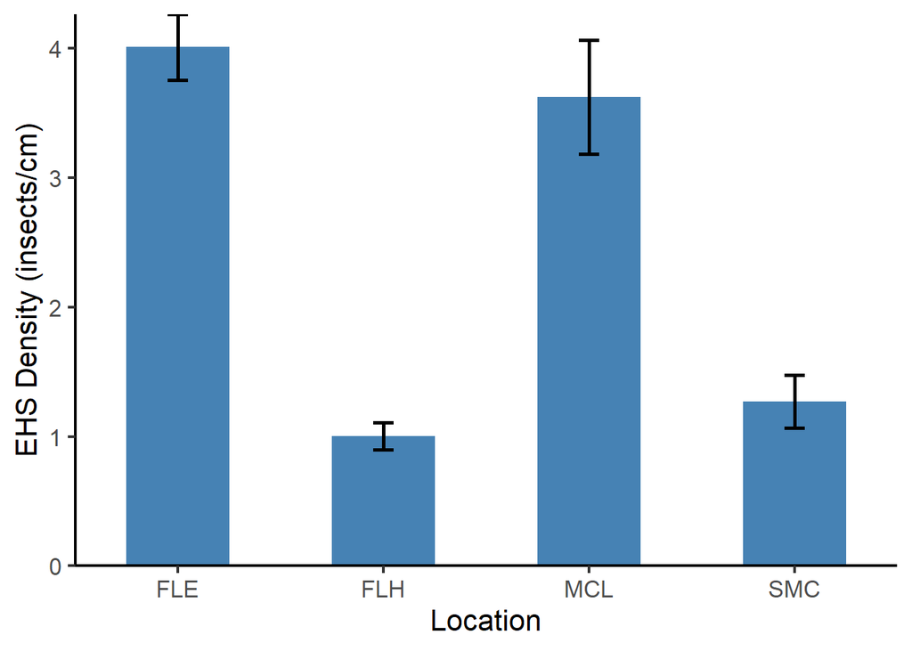

```r
##Bar plot with mean and SE
g.bar <- ggplot(EHS.sum, aes(x=Location,y=mean, fill))+
  geom_bar(stat="identity",  width = 0.5, show.legend=FALSE, fill = "steelblue")+
  geom_errorbar(aes(ymin=mean-sem, ymax=mean+sem), width=0.1, size=1) +
  ylab("EHS Density (insects/cm)") +
  xlab("Location") +
  coord_cartesian(xlim = c(0.5,4.5), expand=FALSE) +
  theme_classic(base_size=16)
print(g.bar)
```

```r
ggsave(path="figures", filename="bar.jpg", height = 7, width = 8, units = "in", dpi = 500)
```

# Histograms

A histogram is only useful when there are enough data points. A good rule of thumb is that a histogram is useful when your sample size in each group is 20-30 or more. If your N < 20 for each group, then it may not be useful to visualize with a histogram.

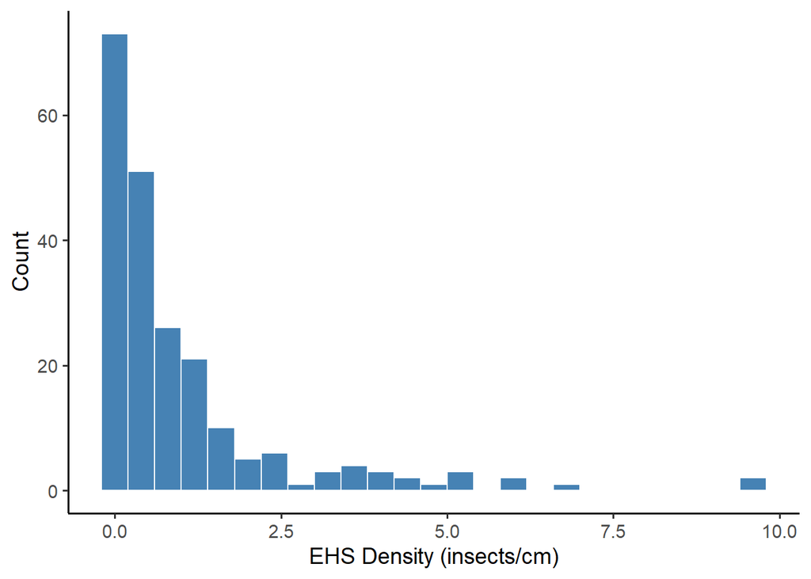

```r
 # To make a histogram of just one location, first you have to filter for a location (in this case FLH)
FLH.data <- hemlock %>% filter(Location == "FLH")

# Histogram of the EHS density at the FLH location
# change the binwidth as needed
FLH.hist <- ggplot(data = FLH.data, aes(x = EHS))+
  geom_histogram(binwidth = 0.4, color = "white", fill = "steelblue", show.legend = FALSE) +
  xlab("EHS Density (insects/cm)") +
  ylab("Count") +
  coord_cartesian(expand=TRUE) +
  theme_classic(base_size=14)
print(FLH.hist)
```

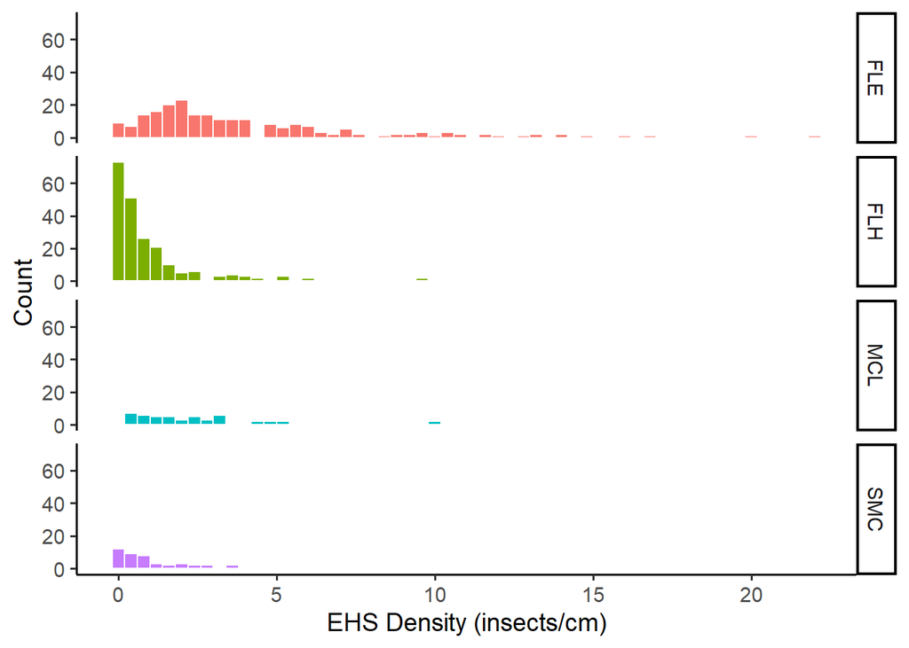

```r
# Histogram of the HWA density for all 4 locations
g.hist <- ggplot(data = hemlock, aes(x = EHS, fill=Location))+
  geom_histogram(binwidth = 0.4, color = "white", show.legend = FALSE) +
  facet_grid(Location ~ .) +
  xlab("EHS Density (insects/cm)") +
  ylab("Count") +
  coord_cartesian(expand=TRUE) +
  theme_classic(base_size=14)
print(g.hist)
```

```r
ggsave(path="figures", filename="histogram.jpg", height = 7, width = 8, units = "in", dpi = 500)
```

# Box Plots

Type ?geom_boxplot in the console or search for geom_boxplot in the help window to pull up the help file. Scroll down to “Summary statistics” to make sure you understand what the box plot is showing and describe ALL the symbols accurately in your figure legend.

Remember, box plots are not useful for very small sample sizes (< 20 or so). You need an absolute minimum of 5 points, but it is better to have more points for a box plot. If your N < 10 for each group, then it is probably not useful to visualize with a box plot.

## Plain Box Plots with Means

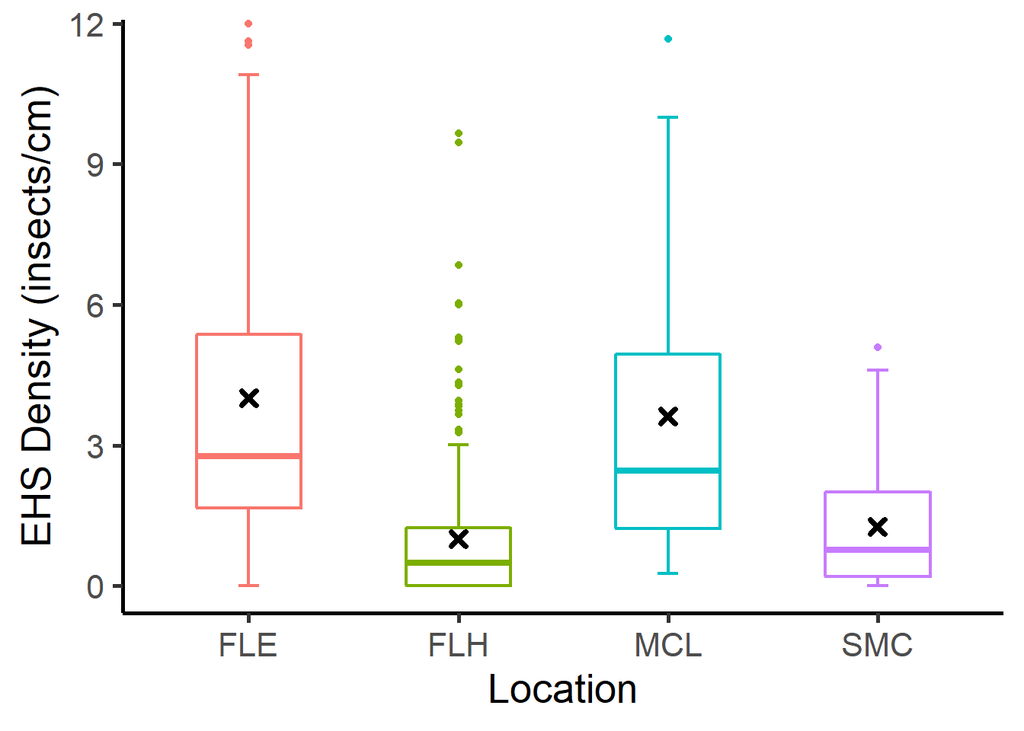

```r
#This code will give a box plot with the mean indicated with an X (erase the stat_summary function if you want to remove the mean)

##Box plot of the EHS density at all 4 locations, X = mean, outliers showing as points
EHS.box <-ggplot(data = hemlock, aes(x= Location, y = EHS, color=Location))+
  stat_boxplot(geom ='errorbar', width = 0.1,  na.rm = TRUE, lwd=0.75, show.legend = FALSE) +
  geom_boxplot(width = 0.5, na.rm = TRUE,lwd=0.75, show.legend = FALSE) +
  stat_summary(fun=mean, geom="point",  shape=4, size=2,
               na.rm = TRUE, show.legend = FALSE, colour = "black", stroke = 2) +
  ylab("EHS Density (insects/cm)") +
  xlab("Location") +
  coord_cartesian(ylim=c(0,11.5),expand=TRUE) +
  theme_classic(base_size=20)
print(EHS.box)
```

```r
ggsave(path="figures", filename="box.jpg", height = 7, width = 8, units = "in", dpi = 500)
```

## Box Plots with Random Jittered Points

This code will give a box plot with the mean indicated and all points are included and randomly jittered to avoid overlapping

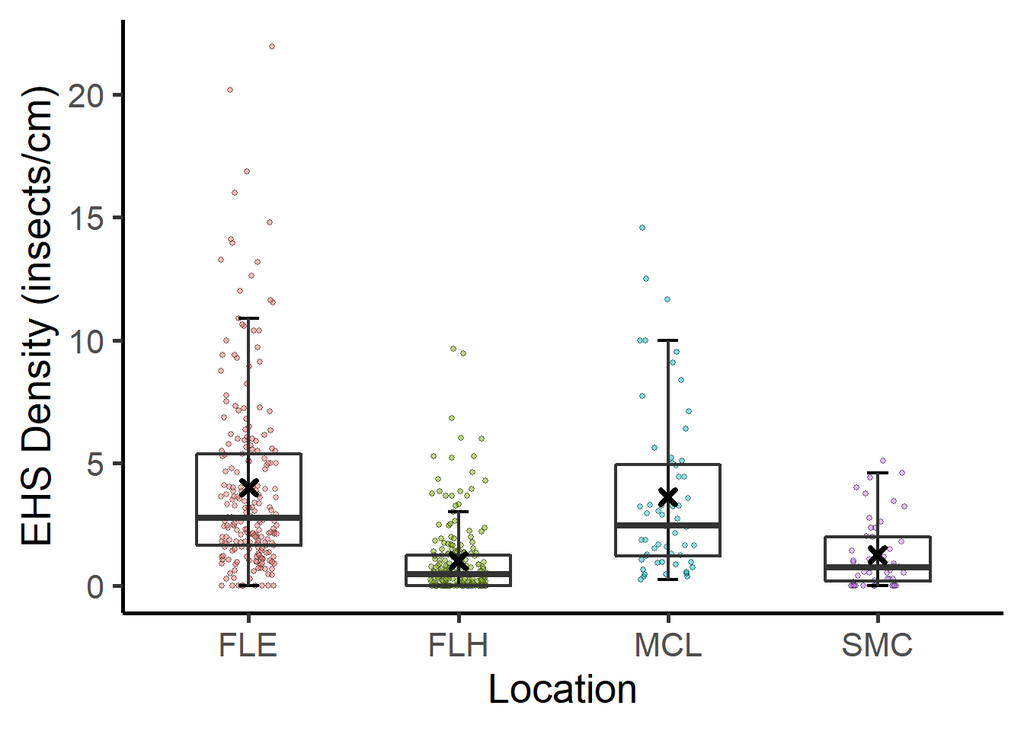

```r
# Box plot of the EHS density at all 4 locations, X = mean, all points randomly jittered
# Erase the stat_summary function if you want to remove the mean
EHS.box2 <-ggplot(data = hemlock, aes(x= Location, y = EHS))+
  geom_point(aes(x= Location, y = EHS, fill = Location), shape=21, size=1, alpha = 0.5,
             position=position_jitterdodge(jitter.width=0.8), show.legend=FALSE) +
  stat_boxplot(geom ='errorbar', width = 0.1,  na.rm = TRUE, lwd=0.75) +
  geom_boxplot(width = 0.5, na.rm = TRUE, outlier.shape= NA, alpha = 0.1, lwd=0.75) +
  stat_summary(fun=mean, geom="point",  shape=4, size=2,
               na.rm = TRUE, show.legend = FALSE, colour = "black", stroke = 2) +
  ylab("EHS Density (insects/cm)") +
  xlab("Location") +
  coord_cartesian(expand=TRUE) +
  theme_classic(base_size=20)
print(EHS.box2)
```

```r
ggsave(path="figures", filename="box_random.jpg", height = 7, width = 8, units = "in", dpi = 500)
```

## Box Plots with symmetric jittered points - beeswarm

This code will give a box plot with the mean indicated and all points are included and symmetrically jittered with beeswarm

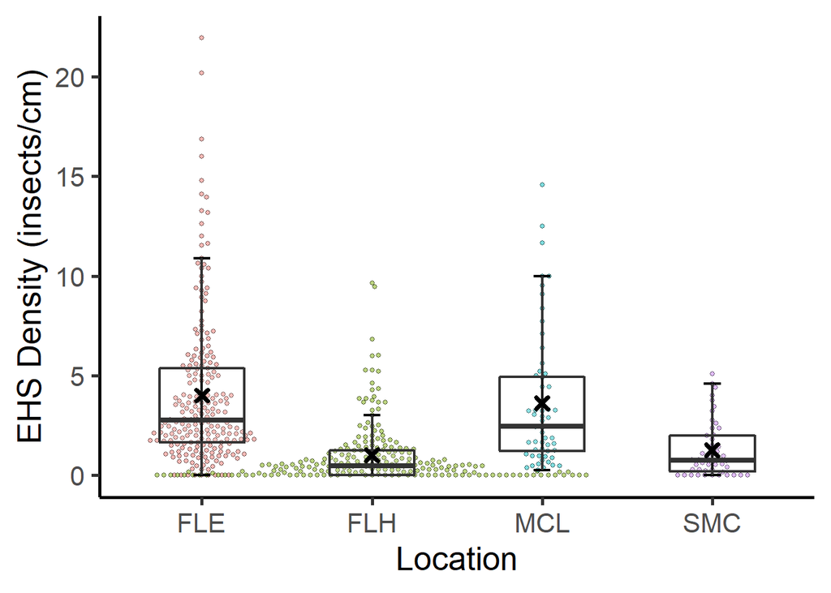

```r
# Box plot of the EHS density at all 4 locations, X = mean,
# all points symmetrically jittered with beeswarm
# Erase the stat_summary function if you want to remove the mean
EHS.box3 <-ggplot(data = hemlock, aes(x= Location, y = EHS))+
  geom_beeswarm(aes(x= Location, y = EHS, fill=Location), shape=21, size=1,
                   alpha=0.5, priority = "random", show.legend=FALSE) +
  stat_boxplot(geom ='errorbar', width = 0.1,  na.rm = TRUE, lwd=0.75) +
  geom_boxplot(width = 0.5, na.rm = TRUE, outlier.shape= NA, alpha = 0.1, lwd=0.75) +
  stat_summary(fun=mean, geom="point",  shape=4, size=2,
               na.rm = TRUE, show.legend = FALSE, colour = "black", stroke = 2) +
  ylab("EHS Density (insects/cm)") +
  xlab("Location") +
  coord_cartesian(expand=TRUE) +
  theme_classic(base_size=20)
print(EHS.box3)
```

```r
ggsave(path="figures", filename="box_beeswarm.jpg", height = 7, width = 8, units = "in", dpi = 500)
```

## Box Plots with symmetric jittered points - quasirandom

This code will give a box plot with the mean indicated and all points are included and symmetrically jittered with quasirandom

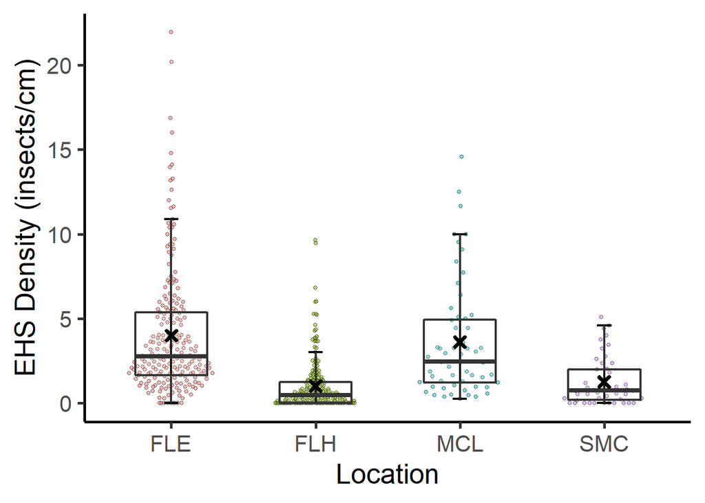

```r
# Box plot of the EHS density at all 4 locations, X = mean,
# all points symmetrically jittered with quasirandom
# Erase the stat_summary function if you want to remove the mean
EHS.box4 <-ggplot(data = hemlock, aes(x= Location, y = EHS))+
  geom_quasirandom(aes(x= Location, y = EHS, fill=Location), shape=21, size=1,
                   alpha=0.5, width=0.3, show.legend=FALSE) +
  stat_boxplot(geom ='errorbar', width = 0.1,  na.rm = TRUE, lwd=0.75) +
  geom_boxplot(width = 0.5, na.rm = TRUE, outlier.shape= NA, alpha = 0.1, lwd=0.75) +
  stat_summary(fun=mean, geom="point",  shape=4, size=2,
               na.rm = TRUE, show.legend = FALSE, colour = "black", stroke = 2) +
  ylab("EHS Density (insects/cm)") +
  xlab("Location") +
  coord_cartesian(expand=TRUE) +
  theme_classic(base_size=20)
print(EHS.box4)
```

```r
ggsave(path="figures", filename="box_quasi.jpg", height = 7, width = 8, units = "in", dpi = 500)
```

# Violin Plots

If the sample size is very large, it can be helpful to use a violin plot that shows the distribution (kind of like a probability density curve mirrored on its side)

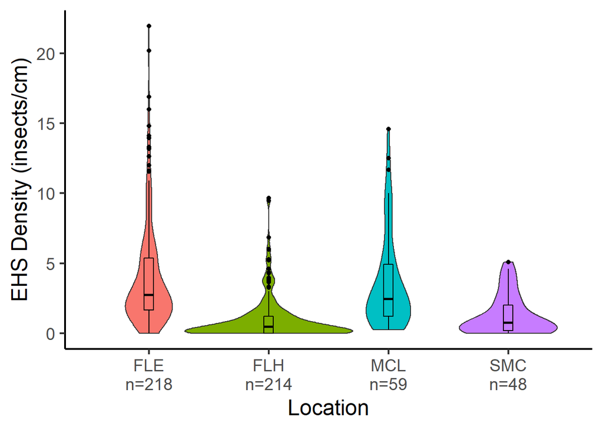

```r
#calculate the sample size for each group first
sample_size = hemlock %>% group_by(Location) %>% summarize (num=n())

#violin plot with box plots and sample sizes
EHS.violin <- hemlock %>%
  left_join(sample_size) %>%
  mutate(myaxis = paste0(Location, "\n", "n=", num)) %>%
  ggplot(aes(x=myaxis, y=EHS, fill=Location)) +
    geom_violin(width=1.4) +
    geom_boxplot(width=0.08, color="black") +
    ylab("EHS Density (insects/cm)") +
    xlab("Location") +
    theme_classic(base_size=18) +
    theme(legend.position="none")
print(EHS.violin)
```

```r
ggsave(path="figures", filename="violin.jpg", height = 7, width = 8, units = "in", dpi = 500)
```

# Dot Plots

An increasingly popular way of visualizing data when the sample size is small enough is to show all the points and a measure of central tendency. Below are three options for how to add points (1) random jitter, (2) beeswarm, (3) quasirandom.

These examples all use the mean, to make graphs with the median, just replace the word mean with median everywhere in the graph.

## Dot Plots with Random Jitter

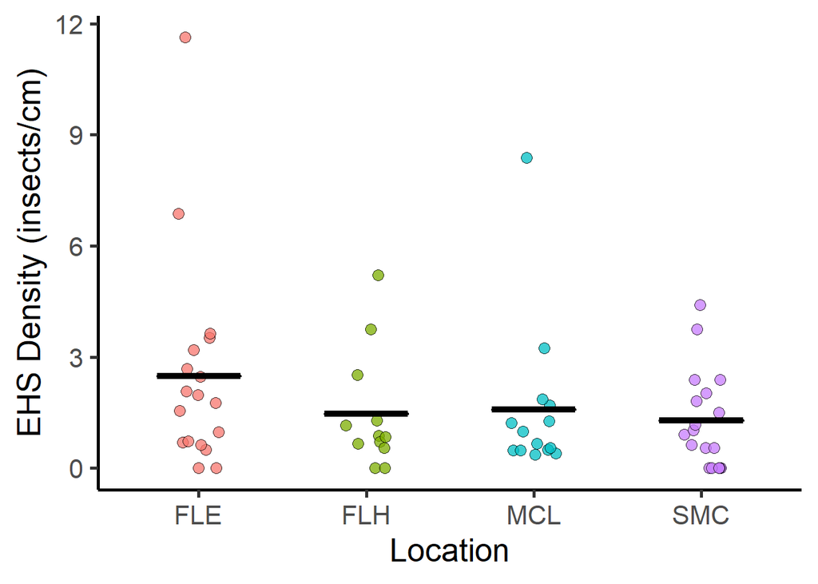

```r
#Filter for one semester (Winter 2019)
hemlock$SamplingDate <- as.Date(hemlock$SamplingDate, "%m/%d/%Y")
small <- hemlock %>% filter (SamplingDate > as.Date("2018-11-20"))

#Dot plot with mean
dot.mean <-  ggplot(data = small, aes(x= Location, y = EHS))+
  geom_point(aes(x= Location, y = EHS, fill = Location), shape=21, size=3, alpha=0.75,
             position=position_jitterdodge(jitter.width=0.8), show.legend=FALSE) +
  stat_summary(fun = mean, fun.min = mean, fun.max = mean, geom = "crossbar",
               width = 0.5, size = 0.75, na.rm = TRUE, show.legend = FALSE, colour = "black") +
  ylab("EHS Density (insects/cm)") +
  xlab("Location") +
  coord_cartesian(expand=TRUE) +
  theme_classic(base_size=20) +
  theme(legend.position="none")
print(dot.mean)
```

```r
ggsave(path="figures", filename="dot.jpg", height = 7, width = 8, units = "in", dpi = 500)
```

## Dot Plots with Symmetric Beeswarm Jitter

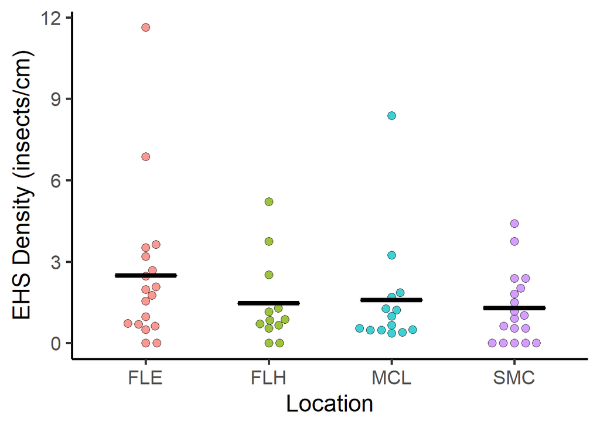

```r
#Filter for one semester (Winter 2019)
hemlock$SamplingDate <- as.Date(hemlock$SamplingDate, "%m/%d/%Y")
small <- hemlock %>% filter (SamplingDate > as.Date("2018-11-20"))

#Dot plot with mean
dot.mean <-  ggplot(data = small, aes(x= Location, y = EHS))+
  geom_beeswarm(aes(x= Location, y = EHS, fill=Location), shape=21, size=3,
                   alpha=0.75, cex=2.25 , priority = "ascending", show.legend=FALSE) +
  stat_summary(fun = mean, fun.min = mean, fun.max = mean, geom = "crossbar",
               width = 0.5, size = 0.75, na.rm = TRUE,
               show.legend = FALSE, colour = "black") +
  ylab("EHS Density (insects/cm)") +
  xlab("Location") +
  coord_cartesian(expand=TRUE) +
  theme_classic(base_size=20) +
  theme(legend.position="none")
print(dot.mean)
```

```r
ggsave(path="figures", filename="dot_beeswarm.jpg", height = 7, width = 8, units = "in", dpi = 500)
```

## Dot Plots with Symmetric Quasirandom Jitter

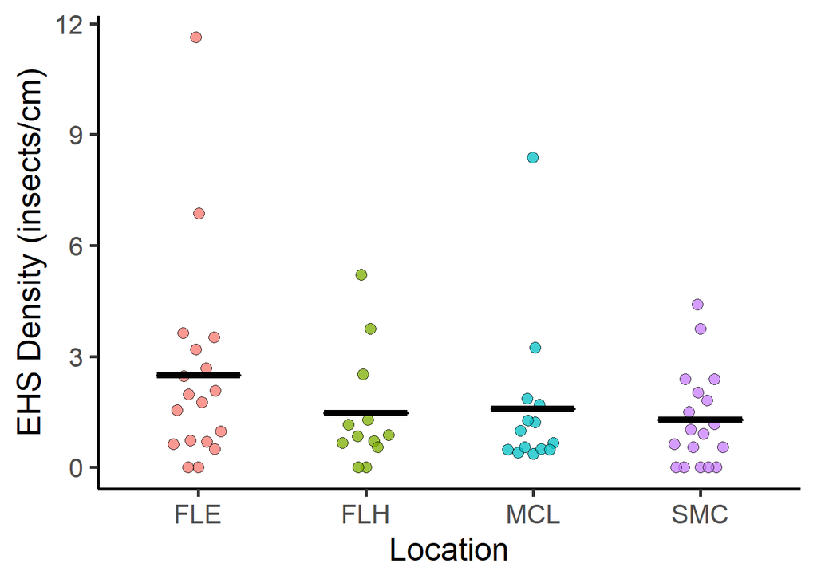

```r
#Filter for one semester (Winter 2019)
hemlock$SamplingDate <- as.Date(hemlock$SamplingDate, "%m/%d/%Y")
small <- hemlock %>% filter (SamplingDate > as.Date("2018-11-20"))

#Dot plot with mean
dot.mean <-  ggplot(data = small, aes(x= Location, y = EHS))+
  geom_quasirandom(aes(x= Location, y = EHS, fill=Location), shape=21, size=3,
                   alpha=0.75, width=0.2, show.legend=FALSE) +
  stat_summary(fun = mean, fun.min = mean, fun.max = mean, geom = "crossbar",
               width = 0.5, size = 0.75, na.rm = TRUE,
               show.legend = FALSE, colour = "black") +
  ylab("EHS Density (insects/cm)") +
  xlab("Location") +
  coord_cartesian(expand=TRUE) +
  theme_classic(base_size=20) +
  theme(legend.position="none")
print(dot.mean)
```

```r
ggsave(path="figures", filename="dot_quasi.jpg", height = 7, width = 8, units = "in", dpi = 500)
```